# Problem Set 1

Sarah Tmimi, Lesley Thomas, Andrew Walsh

2/2/2019

```r
library(ggplot2)
library(dplyr)
```

## Part 1

### Question 1

steps to changing R studio to Black:

1. Tools
2. Global Options
3. Appearance
4. Editor Theme
5. Chaos (or any of the first 3 themes)

### Question 2

finding R packages:

1. Downloading the text posts of twitter:

Found the package `twitteR` by googling for packages that can get text posts from twitter. It implements the entire Twitter API in R, and lets you do things like look at DM’s, friends, posts, search, and more. https://cran.r-project.org/web/packages/twitteR/twitteR.pdf

2. Load an SPSS data file:

I googled how to “load an SPSS data file” and found the website statmethods.net which recommended using the package `Hmisc` to load an SPSS data file. The package can also provide functions for data analysis, advanced table making, conversion of R objects to LaTeX and html code and more. https://cran.r-project.org/web/packages/Hmisc/index.html

3. Annotate street maps:

found the package `ggmaps` by googling “annotating street maps r package”. The package is a collection of functions for vizualizing spatial data from online sources, and includes functions for geolocation and routing. https://cran.r-project.org/web/packages/ggmap/ggmap.pdf

4. Download the text of *The adventures of Sherlock Holms*:

Found a package called `gutenbergr` by googling for packages that can download sherlock holmes. It can download public domain works, information about the works and authors, and ‘pairings’ of work in the Library of Congress. https://cran.r-project.org/web/packages/gutenbergr/vignettes/intro.html

5. Scrape the text off of webpages:

I found the package `rvest` through google, which brought me to a beginner’s guide for Web Scraping. The webpage suggested using `rvest` to easily download and then manipulate HTML and XML. https://cran.r-project.org/web/packages/rvest/index.html

6. Create an animated movie to show how a scatter plot changes over time:

Found the package `gganimate` by googling “r package for creating an animated movie to show how a scatter plot changes over time”. This package wraps aroung ggplot to create animated ggplots. https://www.rdocumentation.org/packages/gganimate/versions/0.1.1

### Question 3

Cleaning up a code chunk:

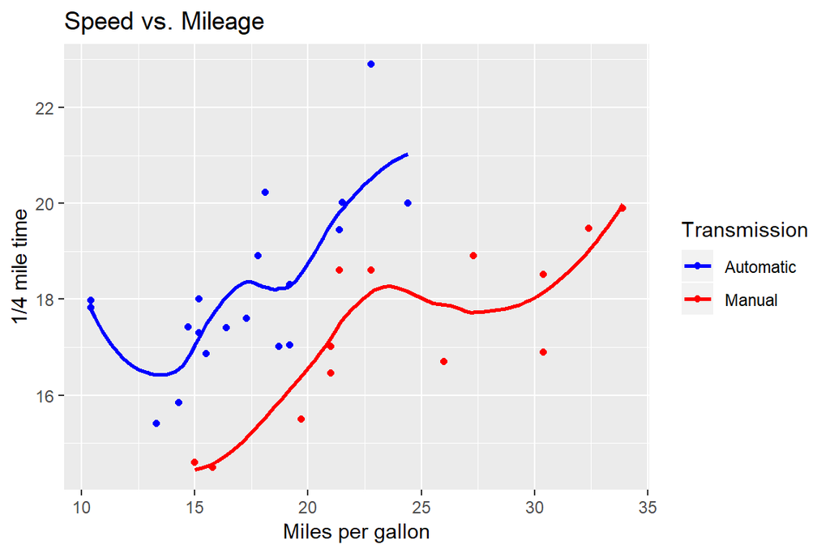

```r
ggplot(mtcars, aes(x=mpg, y=qsec,color=factor(am))) +
  geom_point() +
  geom_smooth(method="loess", se=FALSE) +
  xlab("Miles per gallon") +
  ylab("1/4 mile time") +
  guides(color=guide_legend(title="Transmission")) +
  scale_color_manual(labels =
    c("Automatic", "Manual"), values = c("blue","red")) +
  ggtitle("Speed vs. Mileage")
```

## Part 2

### Question 1

```r
uvawins <- 20

#a
sqrt(uvawins)
```

```
## [1] 4.472136
```

```r
#b
uvawins^3
```

```
## [1] 8000
```

```r
#c
log(uvawins)
```

```
## [1] 2.995732
```

```r
#d
exp(uvawins)
```

```
## [1] 485165195
```

```r
#e
log10((4*(uvawins-5))/9)
```

```
## [1] 0.8239087
```

### Question 2

```r
temps <- c(45, 51, 52, 39, 40, 45, 38)

#a
temps[4]
```

```
## [1] 39
```

```r
#b
((temps - 32)*5)/9
```

```
## [1]  7.222222 10.555556 11.111111  3.888889  4.444444  7.222222  3.333333
```

### Question 3

```r
days <- c("Sunday", "Monday", "Tuesday", "Wednesday", "Thursday", "Friday", "Saturday")

days_temps <- data.frame(days, temps)

days_temps
```

```
##        days temps
## 1    Sunday    45
## 2    Monday    51
## 3   Tuesday    52
## 4 Wednesday    39
## 5  Thursday    40
## 6    Friday    45
## 7  Saturday    38
```

### Question 4

```r
##setwd("~/Desktop/PLAD-4500-PS1")
imdb <- read.csv("imdb.csv")
dim(imdb)
```

```
## [1] 5056   30
```

### Question 5

```r
names(imdb)
```

```
##  [1] "color"                     "director_name"
##  [3] "num_critic_for_reviews"    "duration"
##  [5] "director_facebook_likes"   "actor_3_facebook_likes"
##  [7] "actor_2_name"              "actor_1_facebook_likes"
##  [9] "gross"                     "genres"
## [11] "actor_1_name"              "movie_title"
## [13] "num_voted_users"           "cast_total_facebook_likes"
## [15] "actor_3_name"              "facenumber_in_poster"
## [17] "plot_keywords"             "movie_imdb_link"
## [19] "num_user_for_reviews"      "language"
## [21] "country"                   "content_rating"
## [23] "budget"                    "title_year"
## [25] "actor_2_facebook_likes"    "imdb_score"
## [27] "aspect_ratio"              "movie_facebook_likes"
## [29] "cpi"                       "year"
```

### Question 6

```r
summary(imdb$imdb_score)
```

```
##    Min. 1st Qu.  Median    Mean 3rd Qu.    Max.    NA's
##   1.600   5.800   6.600   6.442   7.200   9.500      13
```

The mean imdb score is 6.442

### Question 7

The two films with the highest IMDB scores are Towering Inferno (9.5) and The Shawshank Redemption (9.3). We shouldn’t trust these scores because the sample size of each is vastly different. ‘The Towering Inferno’ only has 10 reviews while ‘Shawshank Redemption’ has 1689764. The movie with the lowest score is ‘Justin Beiber: Never Say Never’.

### Question 8

```r
str(imdb$movie_title)
```

```
##  Factor w/ 4916 levels "#HorrorÂ ","[Rec] 2Â ",..: 398 2731 3279 3707 3332 1961 3289 3459 399 1631 ...
```

`movie_titles` are a factor class. This is not a good choice for this variable because factors are for categories, but movie titles are words, so it should be a character class.

### Question 9

```r
imdb$movie_title <- as.character(imdb$movie_title)
```

## Part 3: Getting Help

### Question 1

The argument `se` lets you chose whether or not to display the confidence intervals. To change the confidence interval displayed by the function `geom_smooth()` from it’s default of a 95% confidence interval to an 80% confidence interval you would type `level=.80` in parentheses after the command.

### Question 2

https://stackoverflow.com/questions/1741820/what-are-the-differences-between-and-in-r

The writer reccommends using spaces around `<-` because it removes ambiguity. For example, `x<-1` could mean `x <- 1` or `x < -1`.

### Question 3

```r
library(nycflights13)
filter(flights, month == 1, day == 1)
```

```
## # A tibble: 842 x 19
##     year month   day dep_time sched_dep_time dep_delay arr_time
##    <int> <int> <int>    <int>          <int>     <dbl>    <int>
##  1  2013     1     1      517            515         2      830
##  2  2013     1     1      533            529         4      850
##  3  2013     1     1      542            540         2      923
##  4  2013     1     1      544            545        -1     1004
##  5  2013     1     1      554            600        -6      812
##  6  2013     1     1      554            558        -4      740
##  7  2013     1     1      555            600        -5      913
##  8  2013     1     1      557            600        -3      709
##  9  2013     1     1      557            600        -3      838
## 10  2013     1     1      558            600        -2      753
## # ... with 832 more rows, and 12 more variables: sched_arr_time <int>,
## #   arr_delay <dbl>, carrier <chr>, flight <int>, tailnum <chr>,
## #   origin <chr>, dest <chr>, air_time <dbl>, distance <dbl>, hour <dbl>,
## #   minute <dbl>, time_hour <dttm>
```

### Question 4

```r
knitr::include_url("https://www.youtube.com/embed/fhWwBs-W2wk")
```

[video not shown]

Googled how to embed YouTube videos into RMarkdown files, and tried a few of the top results. Then, we realized we needed to use the ‘youtube.com/embed’ form of the url. We stuck with the knitr embed because it’s short and clean.

### Question 5

1. You’re clearly asking a homework question and people don’t like when you do that
2. You haven’t included any information about what you’ve already tried to solve the problem yourself and haven’t explained what error message you’re actualy getting.
3. You didn’t include the version of R you’re using/ what operating system you have.